# `ggplot` basics

Sarah Moore

## Moving to the next element of the tidyverse: `ggplot2`

Last week we discussed `dplyr`, and unbeknownst to all of you we also used `readr` and maybe a couple other parts of `tidyverse` that are all just standard now.

Today we’re not going to *ditch* `dplyr` and all that entirely (for now), but we will shift gears a bit so that we can get to `ggplot2`. Later this week we’ll figure out how to use the two together.

```r
# load tidyverse
library(tidyverse)
```

```r
# check to see that ggplot2 is available among tidyverse packages
tidyverse_packages()
```

# Idea of `ggplot2`

- Based on Grammar of Graphics concepts developed quite a while back.
- Easy, additive way to create graphics.

Base R makes graphics really difficult to implement in an intuitive way. Furthermore, the base R graphics package is NOT very open for customization.

## Motivating Data, pt. 1

This data comes from ACLED. It is conflict event data from Colombia, where each unit of observation is recorded incident of violence perpetrated against civilians.

```r
civ_violence_col<-read_csv("https://raw.githubusercontent.com/sarah-moore/lousy-graphs/main/data/2022_ACLED_civ_colombia.csv")
glimpse(civ_violence_col)
# 5,565 events
```

# To get to know the data, what are some things we should look at?

## Exploring the data

- Let’s find out the unique `year` values available in the data, the unique values of the `admin1` variable, the unique values of the `location` variable, and the summary of the `fatalities` variable.

```r
# years available
summary(civ_violence_col$year) # 2018-2022

# unique admin1
length(unique(civ_violence_col$admin1)) # 32

# unique location
length(unique(civ_violence_col$location)) # 1,066

# summary of fatalities variable

summary(civ_violence_col$fatalities) #min = 0, mean = 1.063, max = 11
```

## Let’s try something in base R first

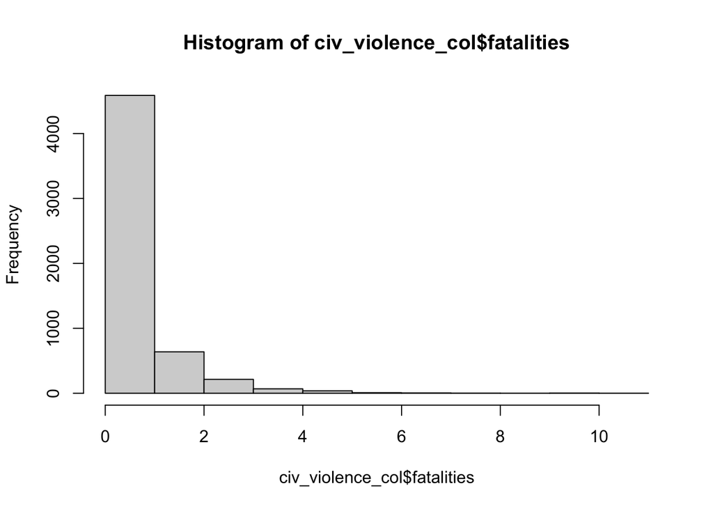

```r
hist(civ_violence_col$fatalities)
```

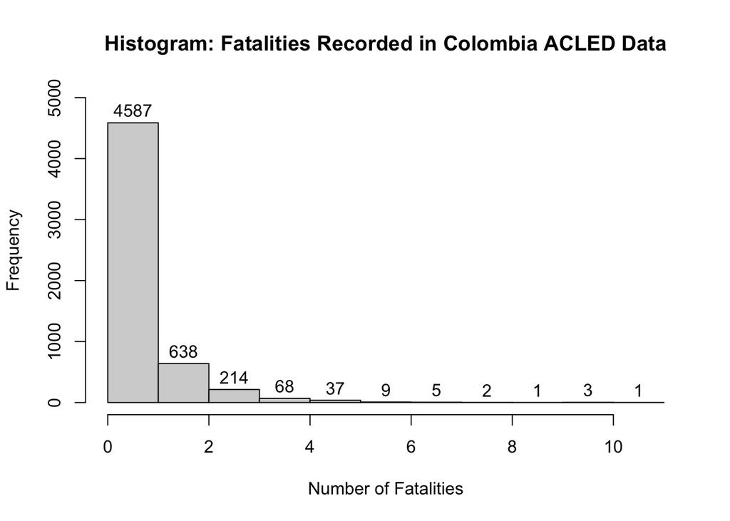

```r
# can further customize title, labels, breaks, etc.

hist(civ_violence_col$fatalities,
     main = "Histogram: Fatalities Recorded in Colombia ACLED Data",
     xlab= "Number of Fatalities", breaks = 11, ylim = c(0,5000),
     labels = T)
```

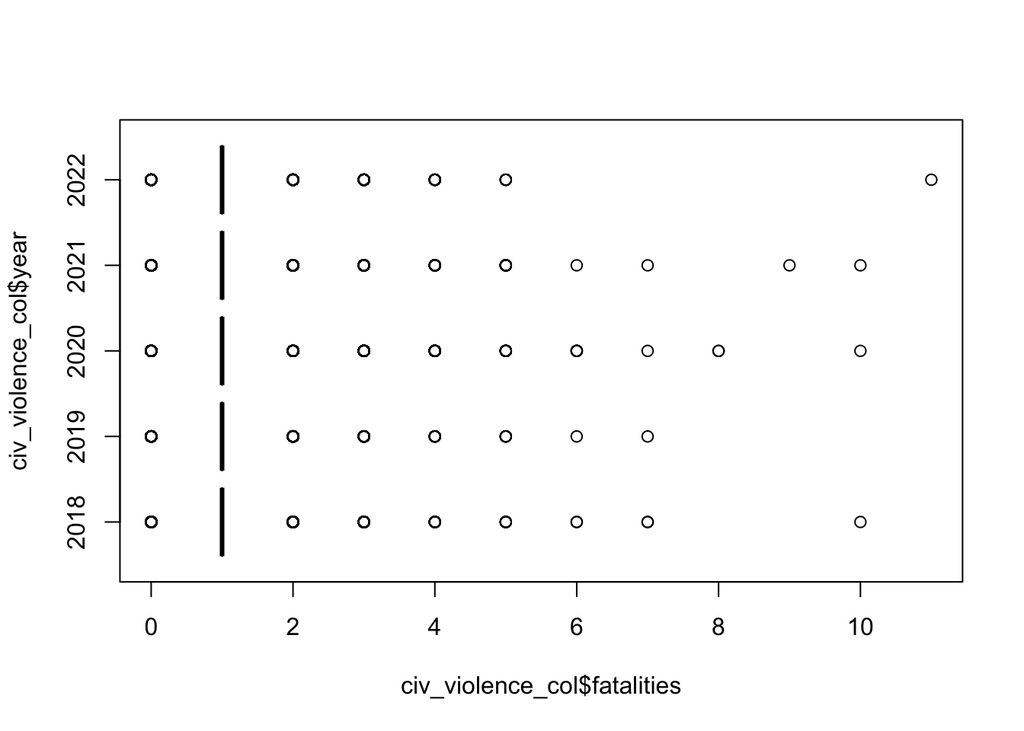

```r
boxplot(civ_violence_col$fatalities~civ_violence_col$year,
        horizontal = T)
```

```r
# not so pretty :(
```

## Let’s try the same with `ggplot2`

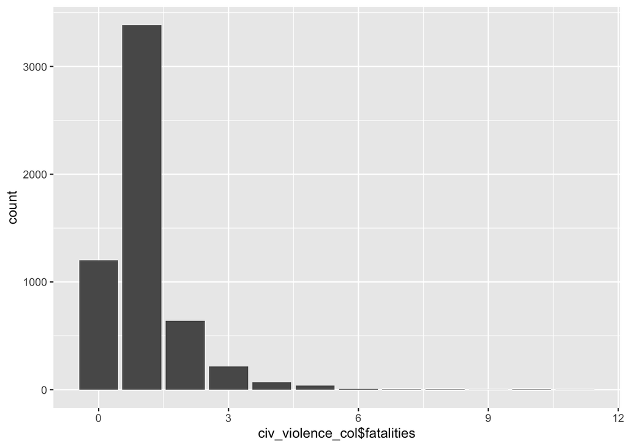

```r
civ_violence_col %>% # start with data
  ggplot(aes(x = civ_violence_col$fatalities)) + # specify data to be plotted
    geom_bar() # specify the type of geometric layer to apply
```

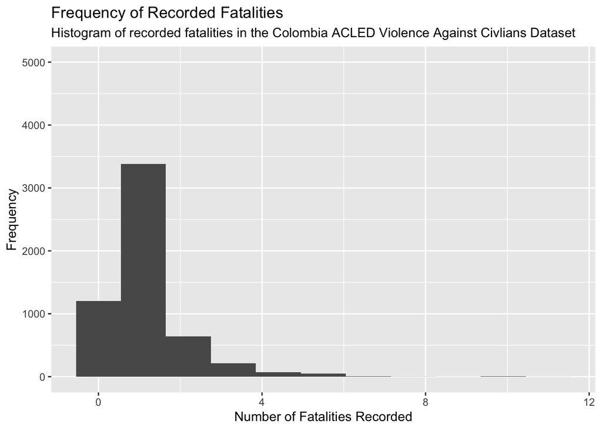

```r
# already looks much better

# now let's add details, can simply add more with + followed by function

civ_violence_col %>%
  ggplot(aes(x = fatalities)) +
  geom_histogram(bins=11) +
  ylim(0, 5000) +
  labs(x = "Number of Fatalities Recorded", y = "Frequency",
       title = "Frequency of Recorded Fatalities",
       subtitle="Histogram of recorded fatalities in the Colombia ACLED Violence Against Civlians Dataset")
```

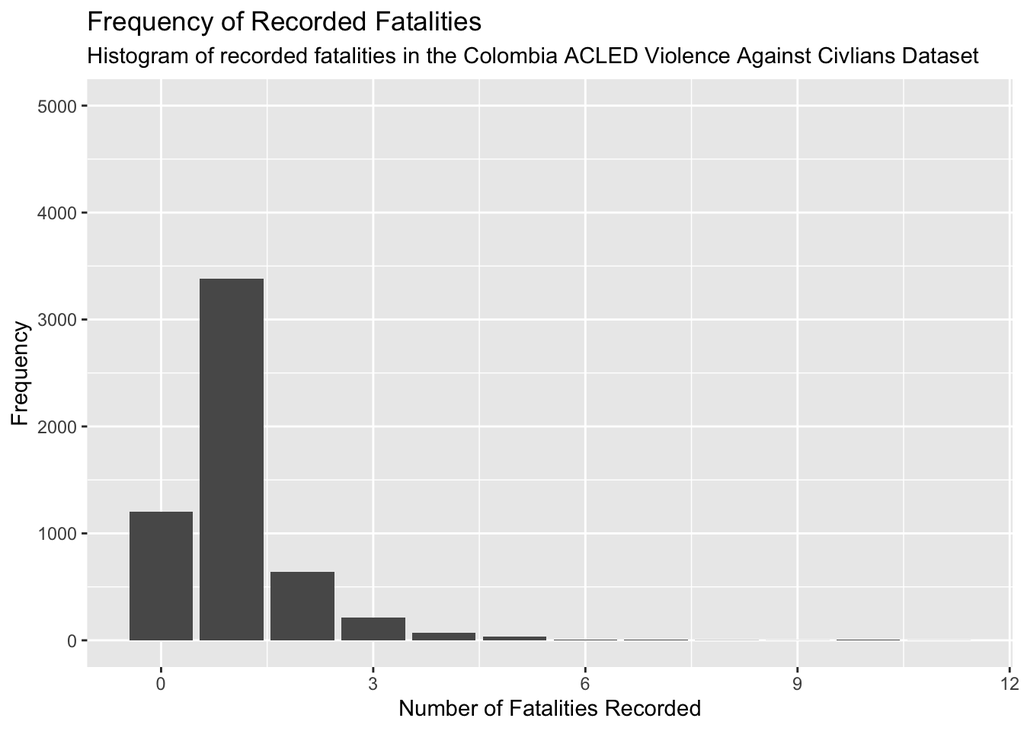

```r
#OR
civ_violence_col %>%
  ggplot(aes(x = fatalities)) +
  geom_bar() +
  ylim(0, 5000)+
  labs(x = "Number of Fatalities Recorded", y = "Frequency",
       title = "Frequency of Recorded Fatalities",
       subtitle="Histogram of recorded fatalities in the Colombia ACLED Violence Against Civlians Dataset")
```

# … what if we want to add more?

Ok, I lied about ditching `dplyr`, here we will go into how to integrate the `dplyr` with `ggplot2`.

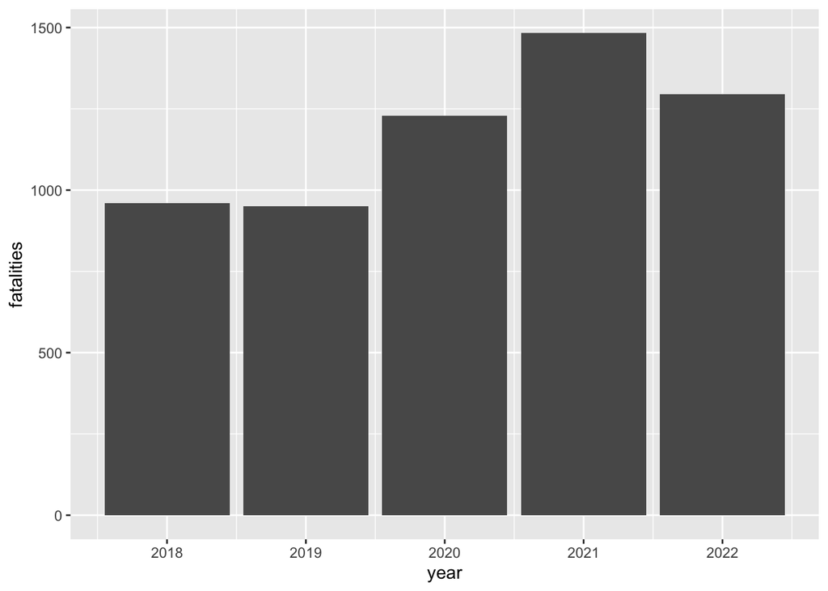

```r
civ_violence_col %>% # start with data
  ggplot(aes(y = fatalities, x = year)) + # specify data to be plotted
    geom_col() # specify the type of geometric layer to apply
```

```r
# let's check this against what we would expect

civ_violence_col %>%
  group_by(year) %>%
  summarize(sum_fatalities = sum(fatalities, na.rm =T))
```

```
## # A tibble: 5 × 2
##    year sum_fatalities
##   <dbl>          <dbl>
## 1  2018            959
## 2  2019            950
## 3  2020           1228
## 4  2021           1483
## 5  2022           1295
```

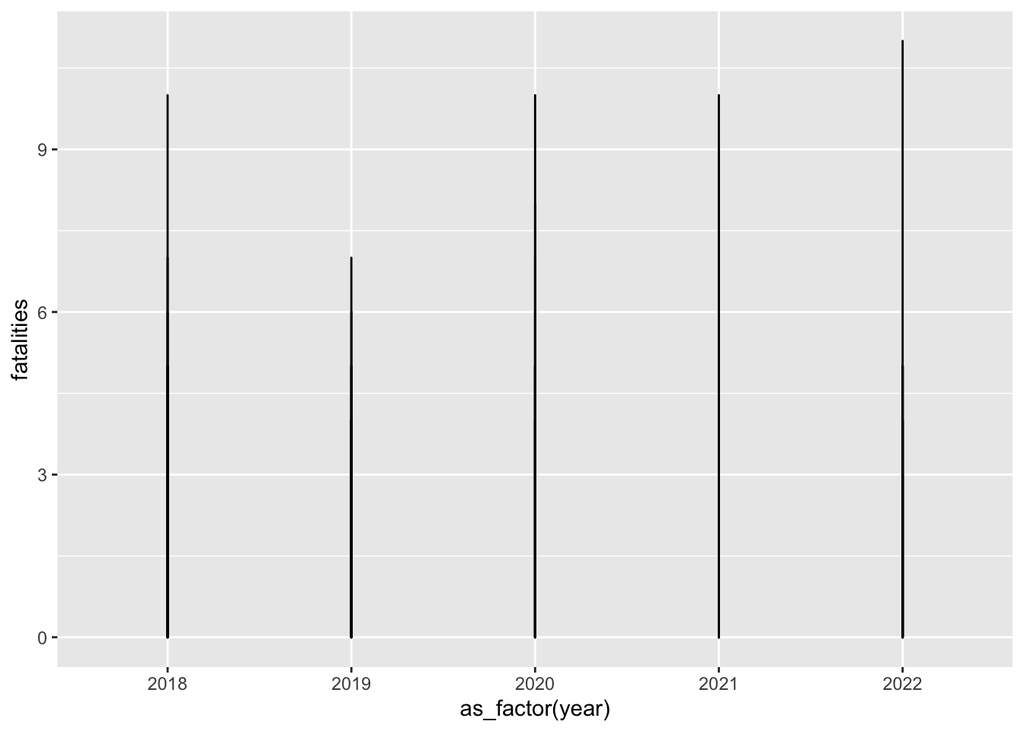

```r
# let's try a different geom_layer

civ_violence_col %>%
  ggplot(aes(x = as_factor(year), y = fatalities)) +
  geom_line()
```

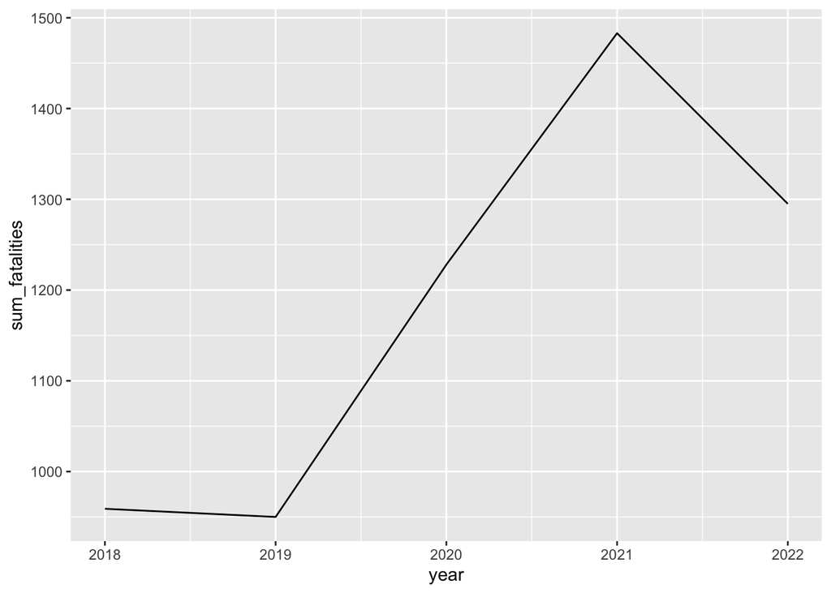

```r
# not great, why? because ggplot is working with the raw data not a summary data.
# need to figure out how to feed it what we want to see

# HERE IS WHERE WE INTEGRATE DPLYR WITH TIDYVERSE

civ_violence_col %>%
  group_by(year) %>%  # manipulate our data starting here with group_by
  summarize(sum_fatalities = sum(fatalities, na.rm =T)) %>% # summarize the data into what we want
  ggplot(aes(x = year, y = sum_fatalities)) + # map out the plot using the summary we created above
  geom_line()
```

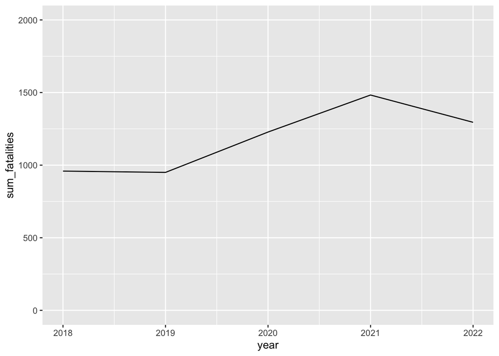

```r
# but, what's misleading about this ^ ?


# can alter the axis!
# notice how this follows that grammar we discussed in the slides

civ_violence_col %>%
  group_by(year) %>%
  summarize(sum_fatalities = sum(fatalities, na.rm =T)) %>%
  ggplot(aes(x = year, y = sum_fatalities)) +
  geom_line() +
  ylim(0,2000)
```

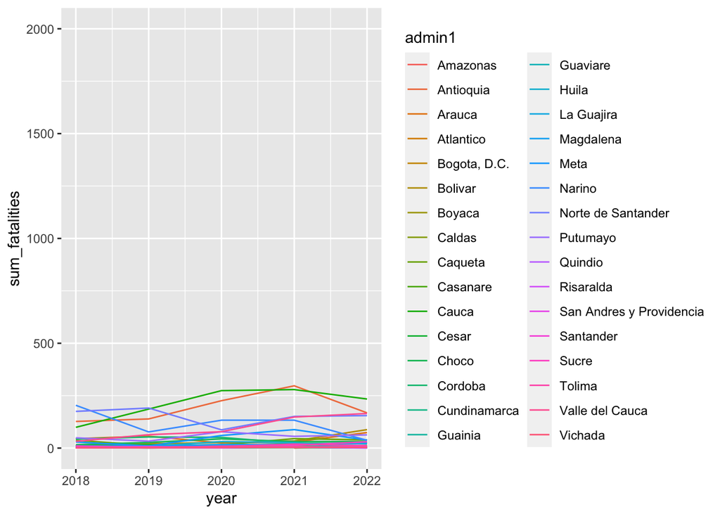

```r
# what if we wanted to add more information

# let's try to see what this looks like by department (the equivalent of a state in Colombia)

civ_violence_col %>%
  group_by(year, admin1) %>%
  summarize(sum_fatalities = sum(fatalities, na.rm =T)) %>%
  ggplot(aes(x = year, y = sum_fatalities, color = admin1)) +
  geom_line() +
  ylim(0,2000)
```

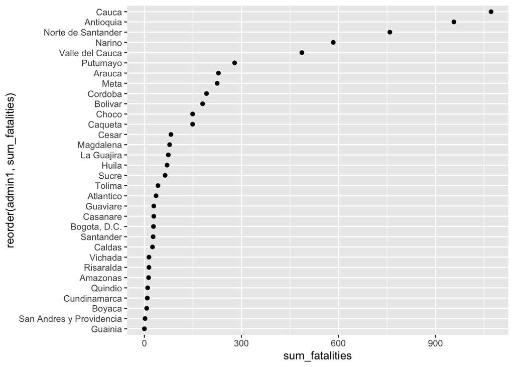

```r
# kind of messy /:

# let's think of a better way

civ_violence_col %>%
  group_by(admin1) %>%
  summarize(sum_fatalities = sum(fatalities, na.rm =T)) %>%
  ggplot(mapping=aes(x=sum_fatalities, y= reorder(admin1, sum_fatalities))) +
  geom_point()
```

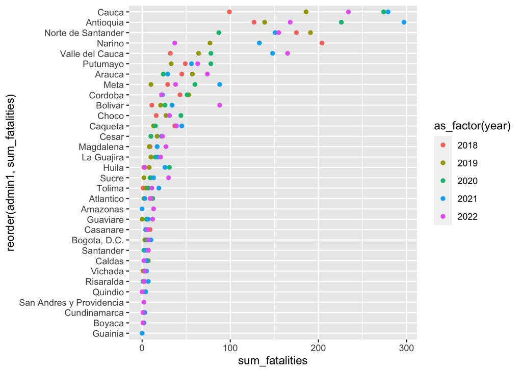

```r
civ_violence_col %>%
  group_by(year, admin1) %>%
  summarize(sum_fatalities = sum(fatalities, na.rm =T)) %>%
  ggplot(mapping=aes(x=sum_fatalities, y= reorder(admin1, sum_fatalities), color = as_factor(year))) +
  geom_point()
```

These are not great examples following what we know about visualization practices. But does it make sense wehre we are going with ggplot?

Let’s keep going.

I, nor many other people, cannot just name off all of the geom layers that exist. Instead, it’s better to have a resource of where to find them, like [this page](https://ggplot2.tidyverse.org/reference).

We already covered geom_bar, geom_col, geom_line, geom_dot… What are some other well suited things for the **univariate case**? What about the **bivariate** or **multivariate** case??

Let’s practice a few more. Doesn’t have to be as complicated above, but we can just feel out a few more examples.

What about a boxplot of the fatalities variable?

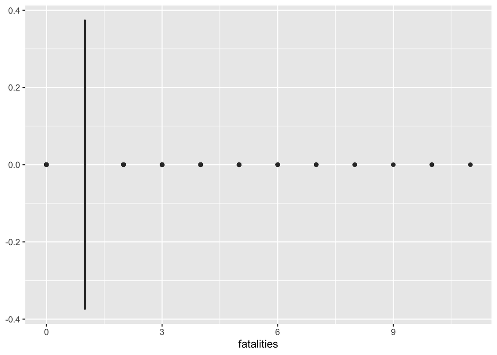

```r
civ_violence_col %>%
  ggplot(aes(x = fatalities)) +
  geom_boxplot()
```

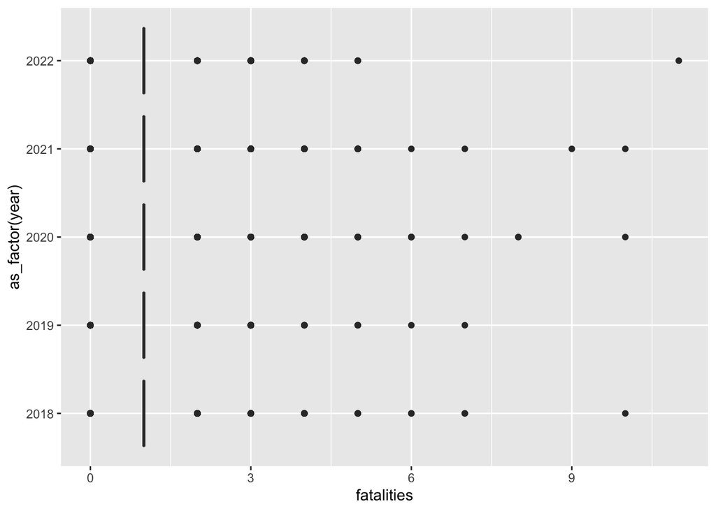

```r
# now let's make it over the years

civ_violence_col %>%
  ggplot(aes(x = fatalities, y= as_factor(year))) +
  geom_boxplot()
```

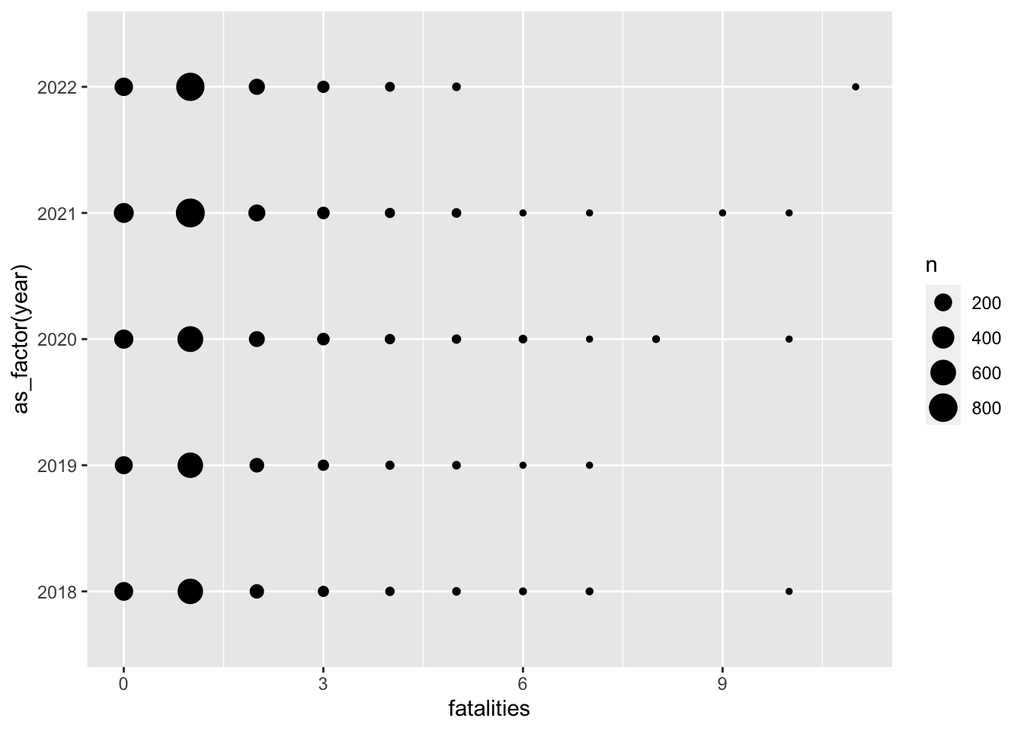

```r
# let's compare this to geom_count()
civ_violence_col %>%
  ggplot(aes(x = fatalities, y= as_factor(year))) +
  geom_count()
```

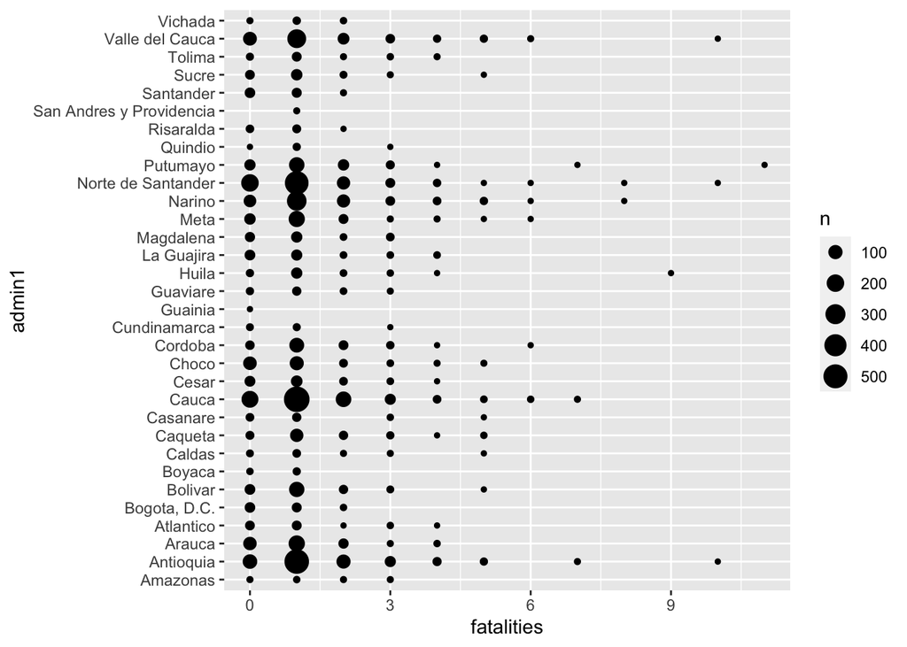

```r
# or add a different specification
civ_violence_col %>%
  ggplot(aes(x = fatalities, y= admin1)) +
  geom_count()
```

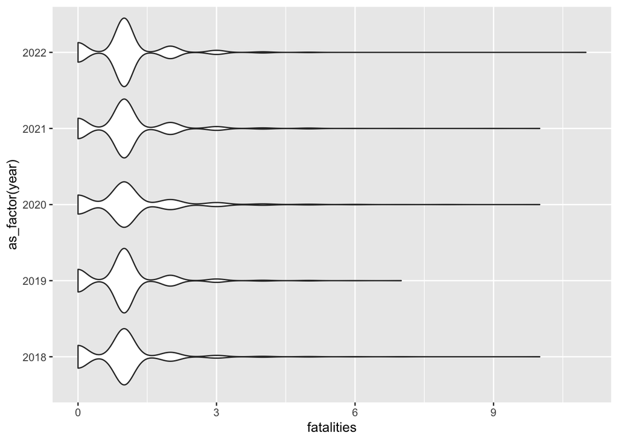

```r
# can also compare to a violin plot

civ_violence_col %>%
  ggplot(aes(x = fatalities, y= as_factor(year))) +
  geom_violin()
```

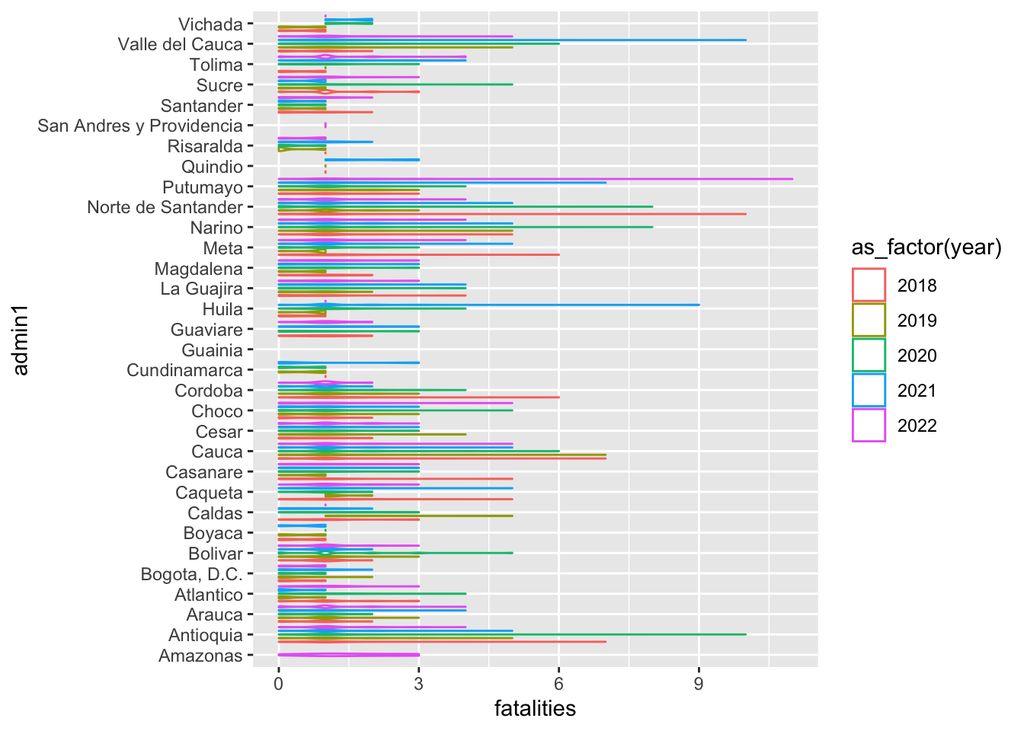

```r
# let's add more information

civ_violence_col %>%
  ggplot(aes(x = fatalities, y= admin1, color = as_factor(year))) +   geom_violin()
```

There is lots of information to be added in the `aes()` mapping specification. Variables, groups, colors, fills. We will continue to play around with this.